# Preprocessing

Brian M. Schilder, Bioinformatician II

2019-02-15

# Setup

```r
# Import functions
root <- "./"
source(file.path(root,"general_functions.R"))
import_parameters(params)
```

```
## **** __Utilized Cores__ **** = 64$subsetGenes
## [1] "protein_coding"
##
## $subsetCells
## [1] "F"
##
## $resolution
## [1] "0.5"
##
## $resultsPath
## [1] "Results/subsetGenes-protein_coding__subsetCells-F__Resolution-0.5__perplexity-30__nCores-64"
##
## $nCores
## [1] 64
##
## $perplexity
## [1] "30"
```

## Load Libraries

```r
library(Seurat)
library(dplyr)
library(gridExtra)
library(knitr)
library(plotly)
library(ggplot2)
library(shiny)
library(DT)
```

```r
print(paste("Seurat ", packageVersion("Seurat")))
```

```
## [1] "Seurat  2.3.4"
```

## Load Data

```r
## ! IMPORTANT! Must not setwd to local path when launching on cluster
# setwd("~/Desktop/PD_scRNAseq/")
load(file.path(root, "Data/seurat_object_add_HTO_ids.Rdata"))
DAT <- seurat.obj
rm(seurat.obj)
```

### Pre-filtered Dimensions

```r
DAT
```

```
## An object of class seurat in project RAJ_13357
##  24914 genes across 22113 samples.
```

## Add Metadata

```r
metadata <- read.table(file.path(root,"Data/meta.data4.tsv"))
createDT( metadata[1:100,], caption = "Metadata")
```

|  | ID | nGene | nUMI | orig.ident | singlet.or.not.binary | percent.mito | res.2 | res.1 | res.0.6 | res.0.3 | barcode | dx | mut | Ethnicity | Gender | Age |
| --- | --- | --- | --- | --- | --- | --- | --- | --- | --- | --- | --- | --- | --- | --- | --- | --- |
| AAAGCAAGTTTGTTGG | BIMD0007 | 784 | 1780 | RAJ_13357 | 1 | 0.0314606741573034 | 3 | 3 | 1 | 0 | AAAGCAAGTTTGTTGG | PD | PD | White | M | 59 |
| TCAGCAATCTTGACGA | BIMD0007 | 742 | 1854 | RAJ_13357 | 1 | 0.0302212628170534 | 18 | 1 | 0 | 0 | TCAGCAATCTTGACGA | PD | PD | White | M | 59 |
| AGCTCCTTCGCGTAGC | BIMD0007 | 495 | 988 | RAJ_13357 | 1 | 0.0404858299595142 | 14 | 7 | 2 | 3 | AGCTCCTTCGCGTAGC | PD | PD | White | M | 59 |
| TATTACCCACTCTGTC | BIMD0007 | 812 | 1874 | RAJ_13357 | 1 | 0.0469583778014941 | 16 | 12 | 7 | 6 | TATTACCCACTCTGTC | PD | PD | White | M | 59 |
| CTCGAGGAGCGATTCT | BIMD0007 | 863 | 2260 | RAJ_13357 | 1 | 0.0212577502214349 | 1 | 0 | 1 | 0 | CTCGAGGAGCGATTCT | PD | PD | White | M | 59 |
| ATAAGAGCATCAGTCA | BIMD0007 | 803 | 2034 | RAJ_13357 | 1 | 0.0216322517207473 | 9 | 8 | 0 | 0 | ATAAGAGCATCAGTCA | PD | PD | White | M | 59 |
| TAGTTGGTCTAACTCT | BIMD0007 | 628 | 1431 | RAJ_13357 | 1 | 0.0286512928022362 | 10 | 3 | 1 | 0 | TAGTTGGTCTAACTCT | PD | PD | White | M | 59 |
| GTACTTTCAGGGTACA | BIMD0007 | 760 | 1802 | RAJ_13357 | 1 | 0.0288728484175458 | 5 | 7 | 2 | 3 | GTACTTTCAGGGTACA | PD | PD | White | M | 59 |
| GACTACATCACCACCT | BIMD0007 | 1223 | 3445 | RAJ_13357 | 1 | 0.0252686610514087 | 20 | 13 | 6 | 5 | GACTACATCACCACCT | PD | PD | White | M | 59 |
| CTTTGCGCACGTAAGG | BIMD0007 | 1066 | 2794 | RAJ_13357 | 1 | 0.0297065139584825 | 7 | 5 | 3 | 1 | CTTTGCGCACGTAAGG | PD | PD | White | M | 59 |

[output cut: 90 more lines]

```r
# Make AgeGroups
makeAgeGroups <- function(){
  dim(metadata)
  getMaxRound <- function(vals=metadata$Age, unit=10)unit*ceiling((max(vals)/unit))
  getMinRound <- function(vals=metadata$Age, unit=10)unit*floor((min(vals)/unit))

  ageBreaks = c(seq(getMinRound(), getMaxRound(), by = 10), getMaxRound()+10)
  AgeGroupsUniq <- c()
  for (i in 1:(length(ageBreaks)-1)){
    AgeGroupsUniq <- append(AgeGroupsUniq, paste(ageBreaks[i],ageBreaks[i+1], sep="-"))
  }
  data.table::setDT(metadata,keep.rownames = T,check.names = F)[, AgeGroups := cut(Age,
                                  breaks = ageBreaks,
                                  right = F,
                                  labels = AgeGroupsUniq,
                                  nclude.lowest=T)]
  metadata <- data.frame(metadata)
  unique(metadata$AgeGroups)
  head(metadata)
  dim(metadata)
  return(metadata)
}
# metadata <- makeAgeGroups()

DAT <- AddMetaData(object = DAT, metadata = metadata)
# Get rid of any NAs (cells that don't match up with the metadata)
if(params$subsetCells==F){
  DAT <- FilterCells(object = DAT,  subset.names = "nGene", low.thresholds = 0)
} else {DAT <- FilterCells(object = DAT,  subset.names = "nGene", low.thresholds = 0,
                    # Subset for testing
                    cells.use = DAT@cell.names[0:params$subsetCells ]
                    )
}
```

```
## Error in 0:params$subsetCells: NA/NaN argument
```

```r
DAT
```

An object of class seurat in project RAJ_13357 24914 genes across 22113 samples.

## Filter & Normalize Data

### Subset Genes by Biotype

Include only subsets of genes by type. Biotypes from: https://useast.ensembl.org/info/genome/genebuild/biotypes.html

```r
subsetBiotypes <- function(DAT, subsetGenes){
  if( subsetGenes!=F ){
    cat(paste("Subsetting genes:",subsetGenes, "\n"))
    # If the gene_biotypes file exists, import csv. Otherwise, get from biomaRt
    if(file_test("-f", file.path(root, "Data/gene_biotypes.csv"))){
      biotypes <- read.csv(file.path(root, "Data/gene_biotypes.csv"))
    }
    else {
      ensembl <- useMart(biomart="ENSEMBL_MART_ENSEMBL", host="grch37.ensembl.org",
                       dataset="hsapiens_gene_ensembl")
      ensembl <- useDataset(mart = ensembl, dataset = "hsapiens_gene_ensembl")
      listFilters(ensembl)
      listAttributes(ensembl)
      biotypes <- getBM(attributes=c("hgnc_symbol", "gene_biotype"), filters="hgnc_symbol",
            values=row.names(DAT@data), mart=ensembl)
      write.csv(biotypes, file.path(root,"Data/gene_biotypes.csv"), quote=F, row.names=F)
    }
    # Subset data by creating new Seurat object (annoying but necessary)
    geneSubset <- biotypes[biotypes$gene_biotype==subsetGenes,"hgnc_symbol"]

    cat(paste(dim(DAT@raw.data[geneSubset, ])[1],"/", dim(DAT@raw.data)[1],
                "genes are", subsetGenes))
    # Add back into DAT
    subset.matrix <- DAT@raw.data[geneSubset, ] # Pull the raw expression matrix from the original Seurat object containing only the genes of interest
    DAT_sub <- CreateSeuratObject(subset.matrix) # Create a new Seurat object with just the genes of interest
    orig.ident <- row.names(DAT@meta.data) # Pull the identities from the original Seurat object as a data.frame
    DAT_sub <- AddMetaData(object = DAT_sub, metadata = DAT@meta.data) # Add the idents to the meta.data slot
    DAT_sub <- SetAllIdent(object = DAT_sub, id = "ident") # Assign identities for the new Seurat object
    DAT <- DAT_sub
    rm(list = c("DAT_sub","geneSubset", "subset.matrix", "orig.ident"))
  }
  return(DAT)
}

DAT <- subsetBiotypes(DAT, params$subsetGenes)
```

```
## Subsetting genes: protein_coding
## 14827 / 24914 genes are protein_coding
```

### Subset Cells

Filter cells and normalize

```r
cat("Total Cells:", length(DAT@cell.names), "\n")
```

[output not shown]

```r
DAT <- FilterCells(object = DAT, subset.names = c("nGene", "percent.mito"),
    low.thresholds = c(200, -Inf), high.thresholds = c(2500, 0.05))
cat("Filtered Cells:", length(DAT@cell.names))
```

```
## Filtered Cells: 19144
```

```r
DAT <- NormalizeData(object = DAT, normalization.method = "LogNormalize",
    scale.factor = 10000)
```

### Subset Genes by Variance

**Important!**: * In ScaleData… + **IMPORTANT!**: *Must* specify do.par = F (“If set to TRUE, will use *half* of the machine’s available cores”) + Specify num.cores = nCores (to use all available cores, determined by parallel::detectCores())

Regress out: number of unique transcripts (nUMI), % mitochondrial transcripts (percent.mito)

```r
# Store the top most variable genes in @var.genes
DAT <- FindVariableGenes(object = DAT, mean.function = ExpMean, dispersion.function = LogVMR,
    x.low.cutoff = 0.0125, x.high.cutoff = 3, y.cutoff = 0.5)
```

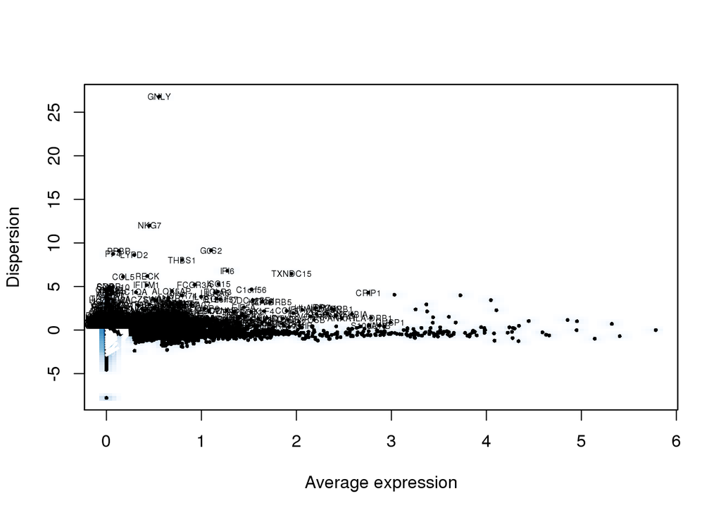

```r
cat("Total Genes:", length(row.names(DAT@raw.data)), "\n")
```

```
## Total Genes: 14827
```

```r
cat("Highly Variable Genes:", length(DAT@var.genes))
```

```
## Highly Variable Genes: 1926
```

```r
# IMPORTANT!: Use only the var.genes identified by 'FindVariableGenes' as the 'gene.use' arg in 'ScaleData'
## This will greatly reduced the computational load.

# Ensure CD14 and CD16 are included
appendedGenes <- c(DAT@var.genes, "CD14", "FCGR3A")
DAT <- ScaleData(object = DAT, genes.use = appendedGenes , vars.to.regress = c("nUMI", "percent.mito"),
                  do.par = F, num.cores = params$nCores)
```

```
##
## Time Elapsed:  18.8049447536469 secs
```

```
## Scaling data matrix
```

### Filtered Dimensions

```r
DAT
```

```
## An object of class seurat in project SeuratProject
##  14827 genes across 19144 samples.
```

# Diagnostic Plots

## Violin Plots

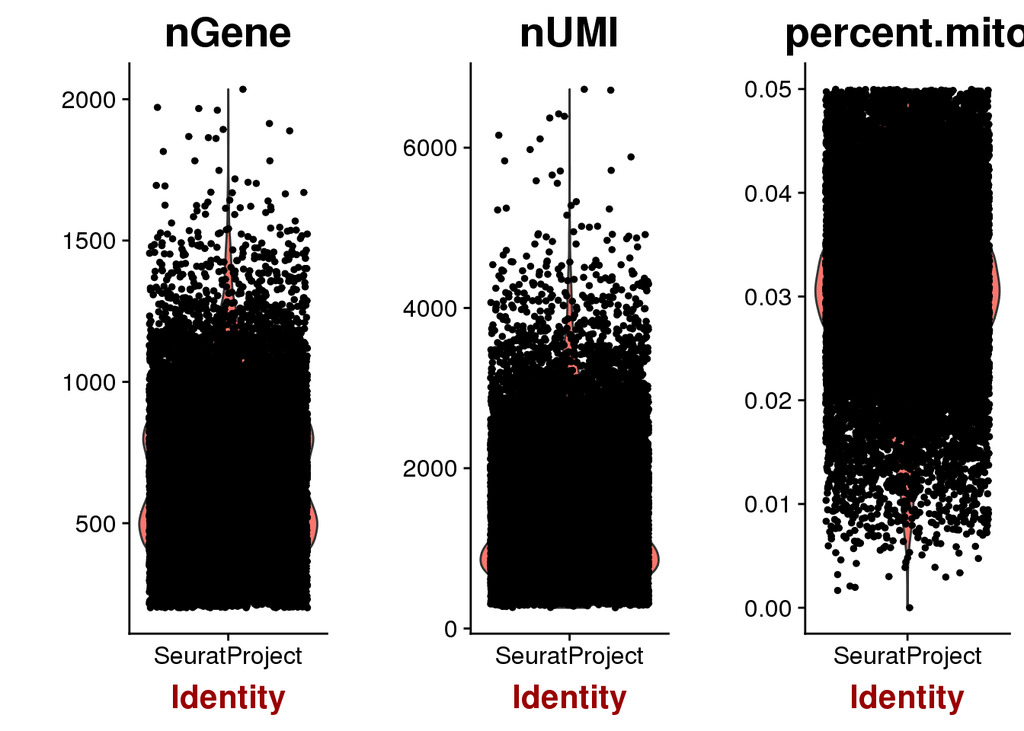

```r
vp <- VlnPlot(object = DAT, features.plot = c("nGene", "nUMI", "percent.mito"),nCol = 3, do.return = T) %>% + ggplot2::aes(alpha=0.5)
vp
```

## Gene Plots

### percent.mito plot

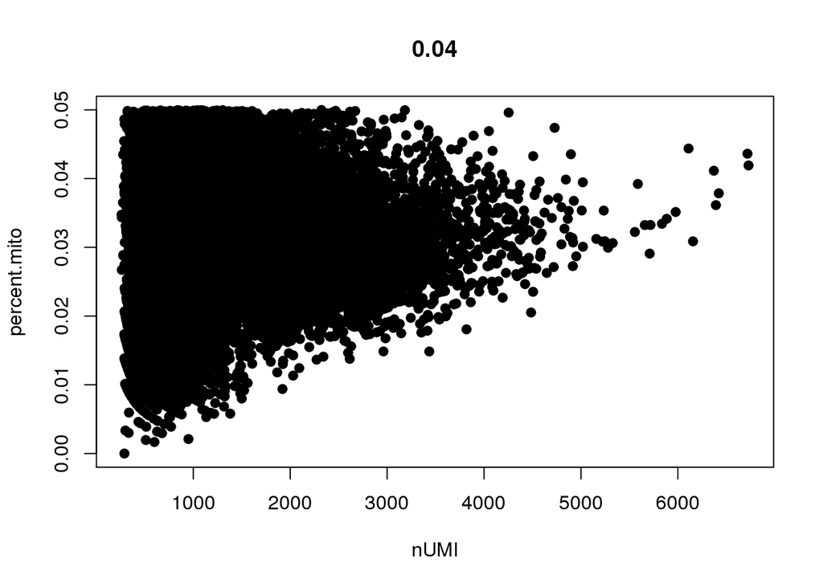

```r
# results = 'hide', fig.show='hide'
# par(mfrow = c(1, 2))
# do.hover <- ifelse(interactive==T, T, F)
GenePlot(object = DAT, gene1 = "nUMI", gene2 = "percent.mito", pch.use=20)
```

```r
         #do.hover=do.hover, data.hover = "mut")
```

### nGene plot

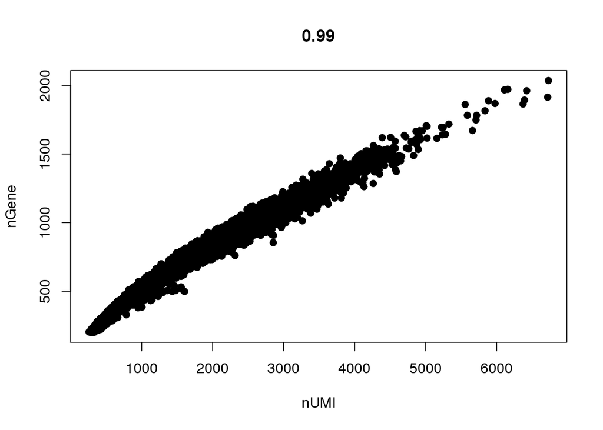

```r
# , results = 'hide', fig.show='hide'
# do.hover <-ifelse(interactive==T, T, F)
GenePlot(object = DAT, gene1 = "nUMI", gene2 = "nGene", pch.use=20)
```

```r
         #do.hover=do.hover, data.hover = "mut")
```

# Dimensionality Reduction & Clustering

## PCA

ProjectPCA scores each gene in the dataset (including genes not included in the PCA) based on their correlation with the calculated components. Though we don’t use this further here, it can be used to identify markers that are strongly correlated with cellular heterogeneity, but may not have passed through variable gene selection. The results of the projected PCA can be explored by setting use.full=T in the functions above

- Other Dim Reduction Methods in Seurat
- RunCCA()
- RunMultiCCA()
- RunDiffusion()
- RunPHATE()
- RunICA()

```r
# Run PCA with only the top most variables genes
DAT <- RunPCA(object = DAT, pc.genes = DAT@var.genes, do.print=F, verbose=F) #, pcs.print = 1:5,  genes.print = 5
# Store in Seurat object so you don't have to recalculate it for the tSNE/UMAP steps
DAT <- ProjectPCA(object = DAT, do.print=F)
```

### VizPCA

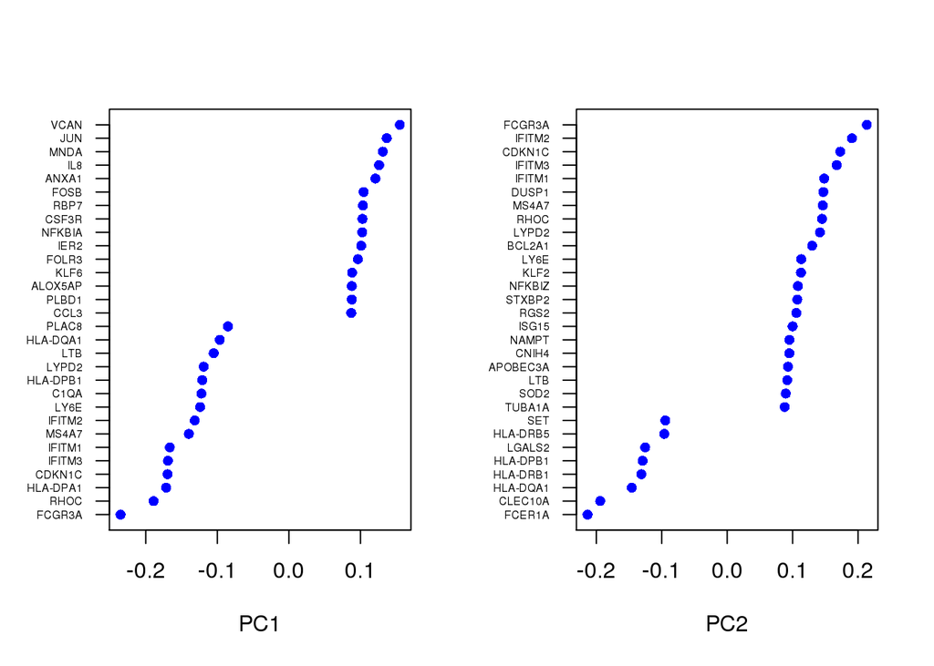

```r
VizPCA(object = DAT, pcs.use = 1:2)
```

### PCHeatmaps

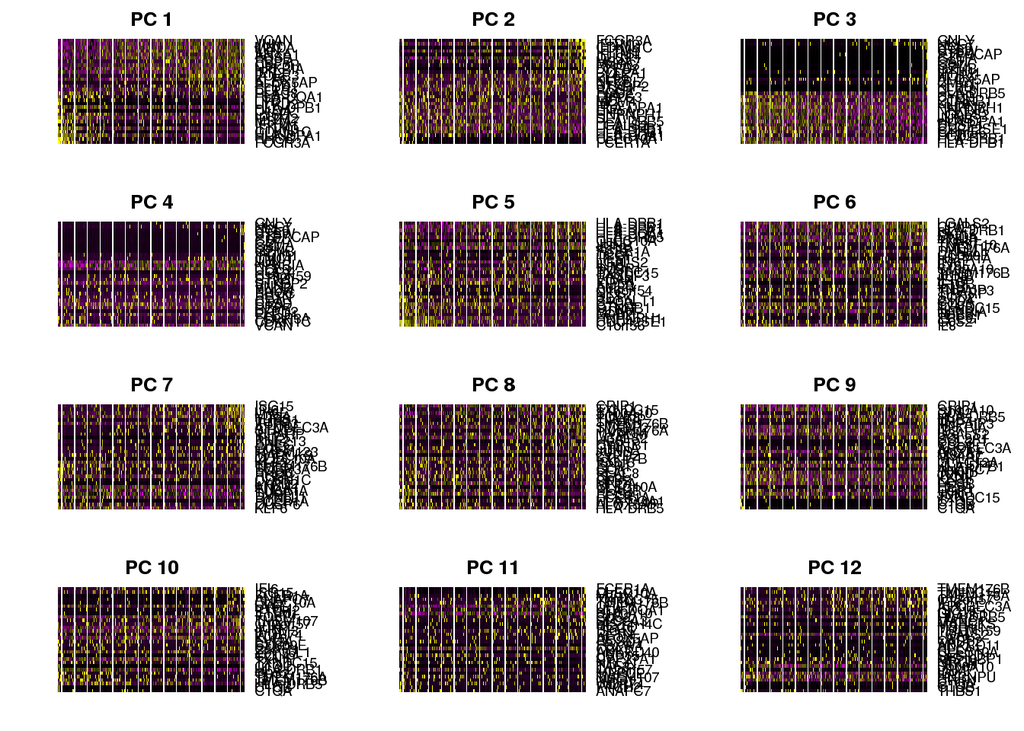

```r
# 'PCHeatmap' is a wrapper for heatmap.2
PCHeatmap(object = DAT, pc.use = 1:12,do.balanced=T, label.columns=F, use.full=F)   # cells.use = 500,
```

### Significant PCs

Determine statistically significant PCs for further analysis. NOTE: This process can take a long time for big datasets, comment out for expediency. More approximate techniques such as those implemented in PCElbowPlot() can be used to reduce computation time

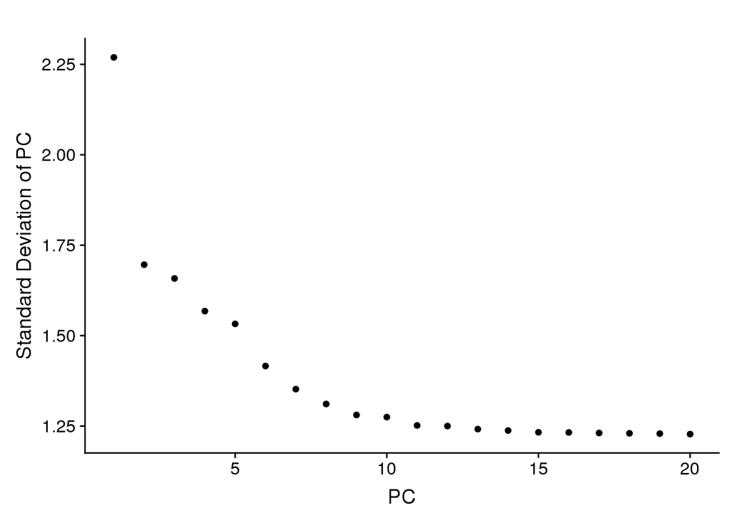

```r
#DAT <- JackStraw(object = DAT, num.replicate = 100, display.progress = FALSE)
PCElbowPlot(object = DAT)
```

## Find Cell Clusters

```r
DAT <- RunTSNE(object=DAT,  reduction.use = "pca", dims.use = 1:10, do.fast = TRUE,
                perplexity = params$perplexity, tsne.method = "Rtsne", num_threads=params$nCores, verbose=F) #   FItSNE
```

```
## Error in 3 * perplexity: non-numeric argument to binary operator
```

```r
# TRY DIFFERENT RESOLUTIONS
DAT <- StashIdent(object = DAT, save.name = "pre_clustering")
# DAT <- SetAllIdent(object = DAT, id = "pre_clustering")

DAT <- FindClusters(object = DAT, reduction.type = "pca", dims.use = 1:10, algorithm = 1,
                     resolution =  params$resolution, print.output = F, save.SNN = T,
                     n.start = 10, nn.eps = 0.5, plot.SNN = T, force.recalc=T)
```

```
## Error in RunModularityClusteringCpp(SNN, modularity, resolution, algorithm, : Not compatible with requested type: [type=character; target=double].
```

```r
PrintFindClustersParams(object = DAT)
```

```
## Error in PrintFindClustersParams(object = DAT): No stored clusterings.
```

```r
DAT <- StashIdent(object = DAT, save.name = "post_clustering")
```